# Do not compound log-returns multiplicatively

*(with Matthias Zuckschwert)*

Some students have compounded log-returns multiplicatively in their theses. This notebook illustrates with a numerical example why this is not appropriate.

Import packages [matplotlib](https://matplotlib.org/) and [pandas_datareader](https://github.com/pydata/pandas-datareader).

```python
import numpy as np
import matplotlib
import matplotlib.pyplot as plt
import pandas_datareader
import pandas_datareader.data as web
print('matplotlib version: ' + matplotlib.__version__)
print('datareader version: ' + pandas_datareader.__version__)
```

```
matplotlib version: 3.5.0
datareader version: 0.10.0
```

Compare the identity $f(x)=x$ with its logarithmic approximation $g(x)=\ln(1+x)$ for $x \in (-1,1.5]$.

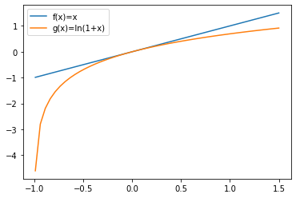

```python
x = np.linspace(-0.99,1.5,50)
plt.plot(x,x, label='f(x)=x')
plt.plot(x,np.log(1+x), label='g(x)=ln(1+x)')
plt.legend()
```

The log is an approximation. This approximation is quite good near zero but deteriorates for values that are not near zero. Thus, when using log returns to approximate simple returns, there is a more significant error for more extreme returns. If you compound log returns multiplicatively in an asset's long-term performance analysis, you would compound all the small errors caused by the logarithm.

Let's look at an example using the value-weighted monthly market returns from [Ken French's data library](https://mba.tuck.dartmouth.edu/pages/faculty/ken.french/data_library.html).

```python
ds = web.DataReader('F-F_Research_Data_Factors', 'famafrench', start='1927-01-01', end='2020-12-31')[0]
mp = (ds['Mkt-RF']+ds['RF'])/100
```

Compute the logarithmic approximation of the simple returns on the market portfolio.

```python
mp_log = np.log(1+mp)
```

Use a scatter plot to compare the simple returns to their logarithmic approximation.

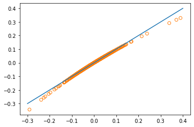

```python
plt.scatter(mp,mp_log, facecolors='none', edgecolors='tab:orange')
x = np.linspace(-0.3,0.4,50)
plt.plot(x,x)
```

Note that the log return is smaller than or equal to the simple return.

How would an investment of $P_0$ currency units perform over time? Recall that the gross return $R_t$ is defined as $R_t = 1 + r_t = \dfrac{P_t}{P_{t-1}}$, where $r_t$ is the simple return. The log-return is defined as $r_t^l = ln\left(\dfrac{P_t}{P_{t-1}}\right)$.

The value of an asset at time $t$ is $P_t = P_{t-1}(1+r_t)$. Over a longer horizon, we get $P_t = P_0 \cdot\prod\limits_{i=1}^{t}(1+r_i)$, where $P_0$ represents the initial investment.

Important: You cannot substitute the simple return $r_i$ in the equation above with the log-return $r_i^l$, that is, you cannot compound log returns multiplicatively. Most of the time, the error is non-negligible.

The following plot shows the performance of the investment of $P_0 = 1$ in the US market (1927-2020). We correctly use the simple returns in equation $P_t = P_0 \cdot\prod\limits_{i=1}^{t}(1+r_i)$ for the blue line. For the orange line, we incorrectly use log-returns.

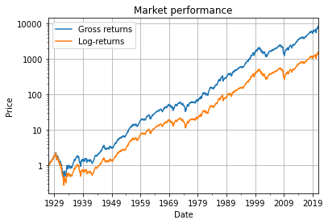

```python
fig1, ax1 = plt.subplots()

(mp+1).cumprod().plot(label='Gross returns')
(mp_log+1).cumprod().plot(label='Log-returns')
ax1.set_yscale('log')
ax1.get_yaxis().set_major_formatter(matplotlib.ticker.ScalarFormatter())
ax1.grid()
ax1.set_title('Market performance')
ax1.set_ylabel('Price')
ax1.set_xlabel('Date')
ax1.legend()
```

The difference in terms of final wealth is huge.

```python
# final wealth of my dollar
(mp+1).cumprod()[-1]
```

```
8531.461037022278
```

```python
# final wealth of my dollar using the log-approximation
(mp_log+1).cumprod()[-1]
```

```
1593.325161370631
```

It is possible to rearrange $P_t = P_0 \cdot\prod\limits_{i=1}^{t}(1+r_i)$ to $P_t = P_0 \cdot e^{\sum_{i=1}^t r_i^l}$.

```python
# correct final wealth using log returns
np.exp(mp_log.cumsum())[-1]
```

```
8531.461037022278
```

Conclusion: Do not compound log-returns multiplicatively.

*Optional Exercise:* Things become worse if returns are more volatile. Show this by comparing a more volatile with a less volatile asset over the same time period or by examining final wealth differences as a function of volatility in simulated data.